# Problem Set 6

Solutions

ECON 316 — Game Theory — Fall 2021

**Note**: Answers may be longer than I would deem sufficient on an exam. Some might vary slightly based on points of interest, examples, or personal experience. These suggested answers are designed to give you both the answer and a short explanation of why it is the answer.

# Concepts

## Question 1

#### What is the difference between a game with **imperfect information** and **incomplete information**?

A game of *imperfect* information is simply a game where the uncertainty comes from what strategy each player has chosen. This can be represented as a simultaneous game in normal/strategic form (payoff matrix) or a sequential game in extended form (game trees) where the second-mover has an information set, indicating they do not know what the first-mover chose.

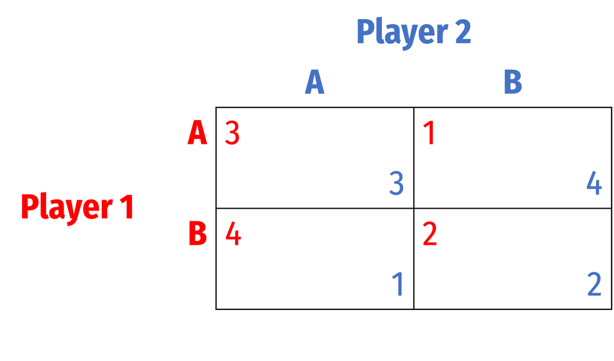

Game in normal form

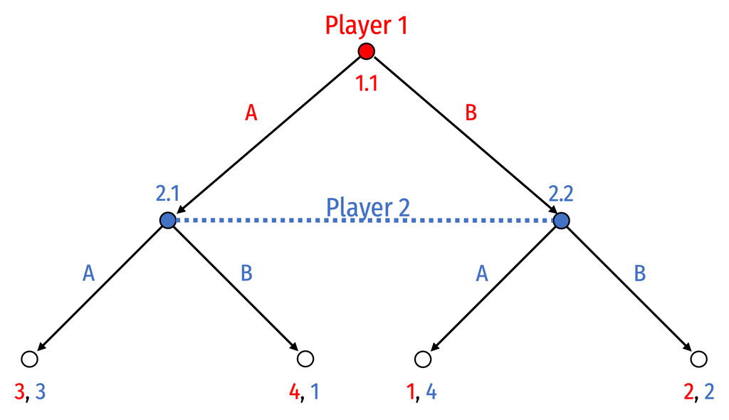

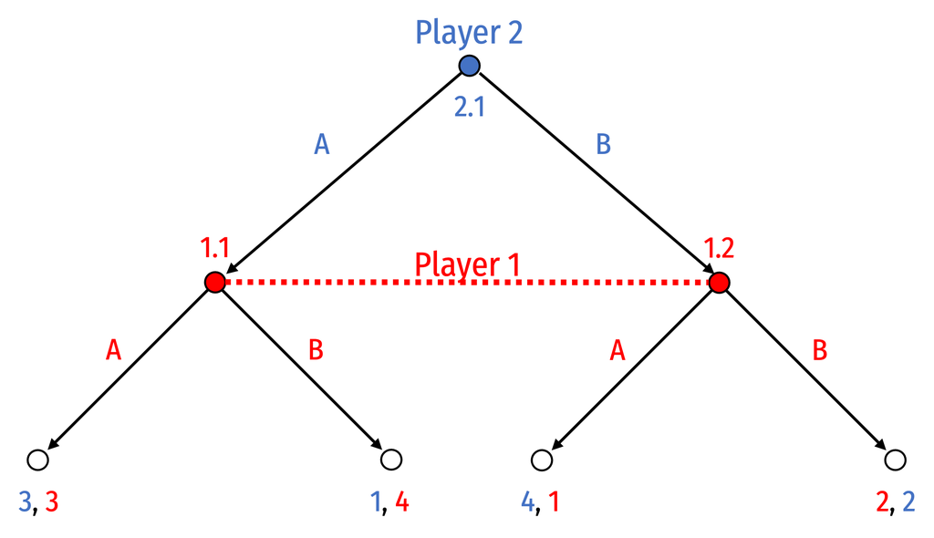

Equivalent game in extensive form(s)

A game of *incomplete* information is a game where all players do not know everything about the game (who the players are, their available strategies, and the payoffs to all strategy-combinations). A common example is a game of **asymmetric information**, where one (informed) player can be a particular type, but the other player (uninformed) does not know the other player’s type. These are called **Bayesian** games because players’ actions (and the equilibria) depend on their *beliefs* about other players.

There are **simultaneous Bayesian games** where players move at the same time (or at least, cannot observe the other player’s move prior to their own decision). In the following spin on the assurance game, both Harry and Sally like Starbucks better than Whitaker. Sally might like Harry, in which case she would like to be at the *same* place as him. She might *not* like him on the other hand, and might *not* like to be at the same place as him. Harry does not know for certain how Sally feels:

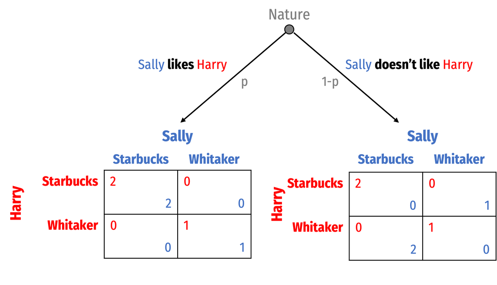

There are also **sequential Bayesian games** where players move in a clear sequence. A **signalling** variant has the informed player move first, and their move is observed by the uninformed player, who then responds. Hopefully, each type of player plays a different move, revealing their type to the uninformed player. A **screening** variant has the uninformed player move first, and their move is observed by the informed player, who then responds. Hopefully, each type of player responds differently to the first move, revealing their type to the uninformed player. Consider below as an example:

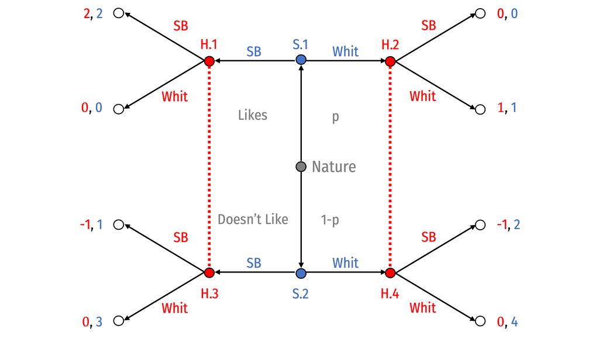

## Question 2

#### Describe the conditions for a **Bayesian Nash Equilibrium (BNE)** and **Perfect Bayesian Nash Equilibrium (PBNE)**. Explain the two types of potential equilibria in any Bayesian game.

Any **Bayesian** game refers to a game with incomplete information. The quintessential example is a game of asymmetric information: one player can be one of two *types* – they know which type they are, but the other player does not. The main difference between **Bayesian Nash equilibrium (BNE)** and **Bayesian Nash Equilibrium (PBNE)** is whether the game being played is simultaneous or sequential, respectively. This is much like the difference between an ordinary Nash equilibrium in a simultaneous game and a *subgame perfect* Nash equilibrium in a sequential game (hence the “perfect”).

In a **Bayesian Nash equilibrium**, each player must be playing their optimal strategy (best response) given the strategies of the other players *and* the uninformed player’s *beliefs* about the other player (i.e. the probability of each type). This is typically accomplished by the uninformed player picking the stratgy that maximizes their *expected* payoff against the informed player (weighed by the probability of each type of player). It consists of:

1. A behavioral strategy profile (i.e. what strategy each (type of) player will play)
2. A belief system (i.e. an estimation of the probability of each type of player)

A **Perfect Bayesian Nash equilibrium** builds on **BNE**, where each player must act in a *sequentially*-rational way (i.e. their optimal strategy survives backwards induction given the optimal responses of the other player) and one that is consistent with their beliefs.

Additionally, we can categorize two categories of Bayesian equilibria for each type of game (simultaneous or sequential):

1. A **pooling equilibrium** where each type of player plays the same strategy.
2. A **separating equilibrium** where each type of player plays a *unique* strategy (compared to other types)

## Question 3

#### Explain the framework of a **signaling** game. What kind of equilibrium is a good signal seeking to attain? (Think back to question 2.) What makes for a good signal? Give some examples.

A signalling game is a sequential game where the informed player (who may be one of several types) moves first, and then the uninformed player moves second. The ideal outcome of a signalling game is a **separating BPNE** where the informed first-mover’s action accurately signals their type to the uninformed second-mover.

A good signal is one that is costly, but more costly for one type of player. Thus, observing the signal clearly identifies to the uninformed player that the informed player is a particular type.

Here are a few examples:

- A foreign merchant signals that s/he is trustworthy by adopting the local practices and customs of the community, so long as it is more costly for dishonest foreign merchants to adopt the practices than an honest merchant
- In Akerlof (1970)’s lemons model: car dealers offering a warranty on a car signals to buyers that the car is high quality, so long as it is less costly for a dealer to offer a warranty on a high-quality car than a low-quality car
- In Spence (1973)’s education model: getting higher education signals to employers that an employee will be a high-ability worker, so long as it is less costly for a high-ability worker to get higher education than a low-ability worker

# Problems

## Question 4

#### A group of police officers have breathalyzers that never fail to detect a truly drunk person. However, the breathalyzer displays false drunkenness in 5% of the cases in which the driver is sober. One in a thousand drivers is driving drunk.

#### Suppose the police officers stop a driver at random, and force the driver to take a breathalyzer test. It indicates that the driver is drunk. Assume we don’t know anything else; *what is the probability the driver truly is drunk?*

#### **Hint**: you will first need to find the probability of a positive result overall, use the law of total probability: $P(B)=P(B|A)P(A)+P(B|\text{Not }A)P(\text{Not }A)$, Drawing a probability tree may also help visualize.

This question is a pure application of **Bayes’ Rule**:
$$P(A|B)=\frac{P(B|A)P(A)}{P(B)}$$

- We want to find: $P(Drunk|+)$
- We know:
  - $P(+|Drunk)=1$
  - $P(+|Sober)=0.05$
  - $P(Drunk)=0.001$
- Bayes’ rule implies:
  $$P(Drunk|+)=\frac{P(+|Drunk)P(Drunk)}{P(+)}$$
- We need to find $P(+)$. Using the law of total probability (see also the probability tree and table to see where this comes from):

$$\begin{align*}
P(+)&=P(+|Drunk)P(Drunk)+P(+|Sober)P(Sober)\\
P(+)&=1(0.001)+0.05(0.999)\\
P(+)&=0.05095\\
\end{align*}$$

[figure not shown]

|  | Drunk | Sober | **Total** |
| --- | --- | --- | --- |
| + | 0.0010 | 0.04995 | 0.05095 |
| - | 0.0000 | 0.94905 | 0.94905 |
| **Total** | 0.0010 | 0.99900 | 1.00000 |

Thus:

$$\begin{align*}
P(Drunk|+)&=\frac{P(+|Drunk)P(Drunk)}{P(+)}\\
&=\frac{1(0.001)}{0.05095}\\
&=0.020\\
\end{align*}$$

## Question 5

Consider the following game: A (partially-drunk) Local is at a bar in the Old West, potentially looking to pick a fight. A Stranger comes to the bar for breakfast. The Stranger is either Tough or Weak, and the Local does not know which. Suppose either type is *equally* likely (i.e. $p=0.50)$. If the Local picks a Fight, the Stranger earns a payoff of 2, and if the Local chooses to Ignore, the Stranger earns 4. The Local earns 0 from Ignoring, 2 from Fighting a *weak* Stranger, and -1 against a *tough* Stranger. The Stranger first decides on breakfast: Quiche (at a cost of 0), or Beer, which costs 1 for a tough and 3 for a weak Stranger. The game is set up in the tree below.

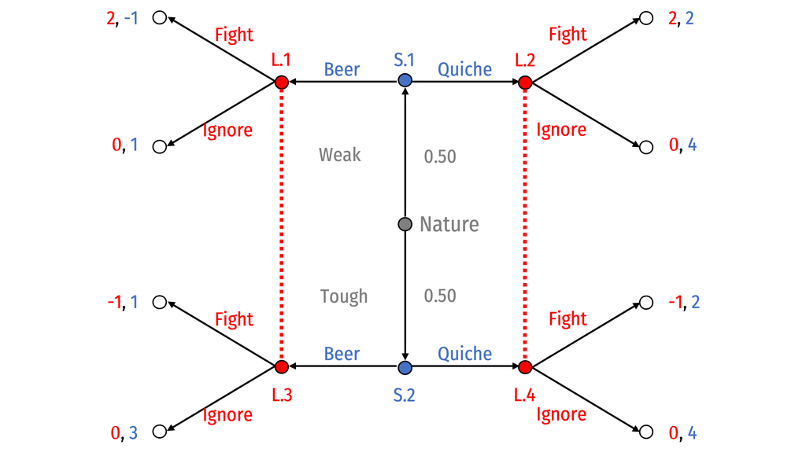

For the questions below, when contemplating a potential a **Bayesian Perfect Nash Equilibrium (BPNE)**, each player must (1) have sequentially rational strategies that consistent with backwards induction and (2) have consistent beliefs about the other player. As hints, for (1), consider Local‘s *expected* payoff to picking a strategy against the two types of Stranger given Stranger’s breakfast selection. For (2), no need to worry about Bayes’ Law here, just think about what beliefs Local must have about Stranger’s type, conditional on observing Stranger’s breakfast choice, in each of the 4 equilibria.

### Part A

#### Under what conditions (if any) can a **pooling BPNE equilibrium** exist where *both* types of Stranger choose Beer?

First, this “Beer-or-Quiche” game actually is a canonical example among game theorists. It originated from a paper based on the satirical 1982 book *Real Men Don’t Eat Quiche* by Bruce Feirstein.

If both types of Stranger choose Beer, Local must believe
$$p(\color{blue}{Tough}|\color{blue}{Beer})=0.5$$

Note that any belief is possible for $p(\color{blue}{Tough}|\color{blue}{Quiche})$, since we never reach the right information set (where Stranger has chosen Quiche)!

That is, conditional on observing the Stranger choose Beer, they are 50% likely to be *tough* (because *all* types of Stranger choose Beer, and 50% of Strangers are *tough*!)

We now consider Local’s expected payoff of Fight vs. Ignore a Beer-drinking Stranger (of unknown type). Recall we know $Prob(tough)=Prob(weak)=p=0.50$.

$$E[\color{red}{Ignore}]=\color{red}{0}(0.5)+\color{red}{0}(0.5)=\color{red}{0}$$

Local gets a higher expected payoff from Fight so that is what they will do against any Beer-drinking Stranger.

Now, a *weak* Stranger, knowing if he chooses Beer will cause a **Fight** (where he earns $\color{blue}{-1})$, would want to *change* to Quiche, since he would earn 2 in a Fight (because Beer costs him 3). Note it would not even matter what Local did in response, since both payoffs of Fight and Ignore under Quiche are preferable to Stranger!

Furthermore, a *strong* Stranger, knowing if he chooses Beer will cause a fight (where he earns $\color{blue}{1})$, would want to *change* to Quiche, since he would earn 2 in a fight (because Beer costs him 1). Note it would not even matter what Local did in response, since both payoffs of Fight and Ignore under Quiche are preferable to Stranger!

Thus, since *both* types of Stranger would *not* want to choose Beer, knowing it is in Local’s best interest to fight any beer-drinker in this scenario, this candidate scenario **can not be a BPNE** since it is **not sequentially rational** for *either* type of Stranger.

### Part B

#### Under what conditions (if any) can a **pooling BPNE equilibrium** exist where *both* types of Stranger choose Quiche?

If both types of Stranger choose Quiche, Local must believe
$$p(\color{blue}{Tough}|\color{blue}{Quiche})=0.5$$

Note that any belief is possible for $p(\color{blue}{Tough}|\color{blue}{Beer})$, since we never reach the left information set (where Stranger has chosen Beer)!

That is, conditional on observing the Stranger choose Quiche, they are 50% likely to be *tough* (because *all* types of Stranger choose Quiche, and 50% of Strangers are *tough*!)

We now consider Local’s expected payoff of Fight vs. Ignore a Quiche-eating Stranger (of unknown type). Recall we know $Prob(tough)=Prob(weak)=p=0.50$.

$$E[\color{red}{Ignore}]=\color{red}{0}(0.5)+\color{red}{0}(0.5)=\color{red}{0}$$

Local gets a higher expected payoff from Fight so that is what they will do against any Quiche-eating Stranger.

Here is the only slight difficulty: a *strong* Stranger, knowing if he chooses Quiche will cause a Fight (where he earns $\color{blue}{2}$), might actually want to switch to Beer if Local were to Ignore (then Stranger would earn 3)…This would upset our scenario as a possible equilibrium. For it to remain an equilibrium, Local would have to believe $p(\color{blue}{Weak}|\color{blue}{Beer})=1$, that is, any Beer-drinker must be *weak*, and thus he would provoke a Fight. This belief would keep a *strong* Stranger from wanting to switch from Quiche to Beer.

With these conditions, since *both* types of Stranger would not want to switch to Beer, this outcome can be sequentially rational. Thus, this **pooling PBNE** is possible under the following conditions:

1. Behavioral strategy profile: {(Beer: Fight, Quiche: Fight), (Tough: Quiche, Weak: Quiche)}
2. Beliefs:
   - $p(Tough|Quiche)=0.5$
   - $p(Weak|Beer)=1$

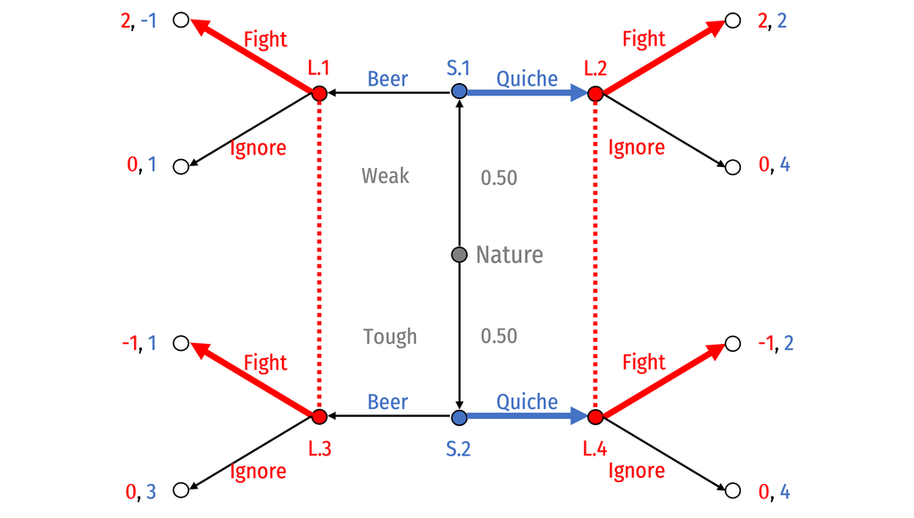

### Part C

#### Under what conditions (if any) can a **separating BPNE equilibrium** exist where a *weak* Stranger chooses Beer and a *tough* Stranger chooses Quiche?

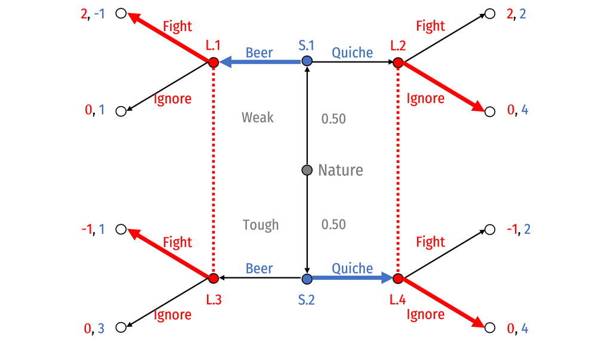

Our assessment

If only weak Strangers choose Beer and tough Strangers choose Quiche, Local must believe

$$\begin{align*}
p(\color{blue}{Tough}|\color{blue}{Quiche})&=1\\
p(\color{blue}{Weak}|\color{blue}{Beer})&=1\\
\end{align*}$$

If that is the case, consider Local’s response to observing a Stranger choose Quiche: Local would know this Stranger is *tough*, and would thus want to Ignore and earn 0 over Fight (which earns him only -1).

Next, consider Local’s response to observing a Stranger choose Beer: Local would know this Stranger is *weak*, and would thus want to Fight and earn 2 over Ignore (which earns him only 0).

Given these reactions, a *tough* Stranger, knowing Local will Ignore if he orders Quiche and Fight if he orders Beer, prefers Quiche which earns him 4 over Beer (where he would earn only 1).

A *weak* Stranger, knowing Local will Ignore if he orders Quiche and Fight if he orders Beer, actually prefers to **switch** to Quiche which earns him 4 over Beer (where he would earn -1).

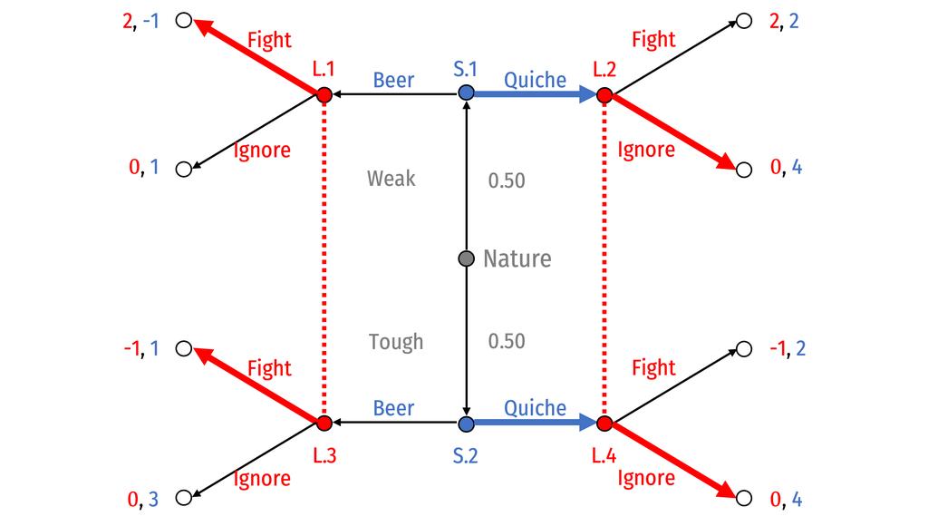

### Part D

#### Under what conditions (if any) can the **separating BPNE equilibrium** exist where a *weak* Stranger chooses Quiche and a *tough* Stranger chooses Beer?

If only weak Strangers choose Quiche and tough Strangers choose Beer, Local must believe:

$$\begin{align*}
p(\color{blue}{Tough}|\color{blue}{Beer})&=1\\
p(\color{blue}{Weak}|\color{blue}{Quiche})&=1\\
\end{align*}$$

If that is the case, consider Local’s response to observing a Stranger choose Quiche: Local would know this Stranger is *weak*, and would thus want to Fight and earn 2 over Ignore (which earns him only 0).

Next, consider Local’s response to observing a Stranger choose Beer: Local would know this Stranger is *tough*, and would thus want to Ignore and earn 0 over Fight (which earns him only-1).

Given these reactions, a *tough* Stranger, knowing Local will Fight if he orders Quiche and Ignore if he orders Beer, prefers Beer which earns him 3 over Quiche (where he would earn only 2).

A *weak* Stranger, knowing Local will Fight if he orders Quiche and Ignore if he orders Beer, prefers Quiche which earns him 2 over Beer (where he would earn only 1). Thus, this **separating PBNE** is possible under the following conditions:

1. Behavioral strategy profile: {(Beer: Ignore, Quiche: Fight), (Tough: Beer, Weak: Quiche)}
2. Beliefs:
   - $p(Tough|Beer)=1$
   - $p(Weak|Quiche)=1$

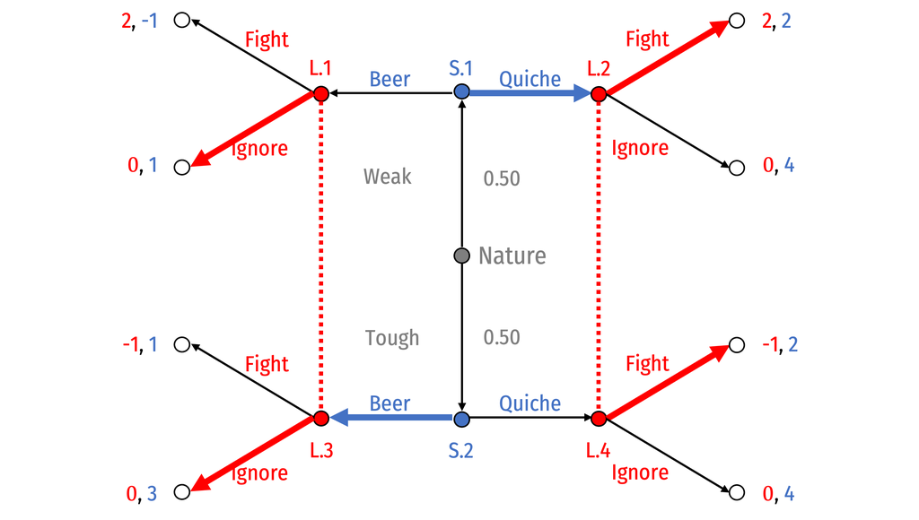

### Part E

#### Describe why the signal sent in this game can successfully achieve a separating equilibrium.

The separating equilibrium in part d — where weak strangers order quiche and tough strangers order beer — is achieved precisely since the question prompt states that:

1. Ordering beer is costly (where quiche is free)
2. Beer costs *more* to a *weak* type ($-3$) vs. a *tough* type ($-1$)

Thus, while weak types may want to pretend they are tough (and discourage a fight) by ordering beer, it is too costly for them to imitate tough types since it costs them more to order a beer than it would a tough type.